# R Bootcamp: Day 3 AM

## Data visualization: base R and ggplot2

Yufei Qin

Eric Manning

September 1, 2026

[figure not shown]

princeton-ddss.github.io/r-bootcamp

## This session

### 2) `ggplot2`

- Plots as objects, built from layers
- Geoms, facets, scales, and labels
- Making and saving publication-ready figures

Conclude with Quarto report exercise

## Some sources

- Wickham, Çetinkaya-Rundel, and Grolemund, *R for Data Science*, 2e
  - [Ch. 1: Data visualization](https://r4ds.hadley.nz/data-visualize.html)
  - [Ch. 9: Layers](https://r4ds.hadley.nz/layers.html)
- Harvard IQSS, *Math Prefresher for Political Scientists*
  - [Ch. 10: Visualization](https://iqss.github.io/prefresher/14_visualization.html)
- `ggplot2` documentation
  - [Function reference](https://ggplot2.tidyverse.org/reference/) — every geom, scale, and theme
  - [Aesthetic specifications](https://ggplot2.tidyverse.org/articles/ggplot2-specs.html) — every point shape, line type, and color name

# Base R plots

## Our data, again

The county data from yesterday — income and rent, plus population and region:

```r
counties <- left_join(
    read_csv("data/county_data.csv"),
    read_csv("data/county_population.csv"),
    join_by(GEOID == fips)
)
```

## Our data, again

```r
glimpse(counties)
```

```
Rows: 3,144
Columns: 10
$ GEOID      <chr> "01001", "01003", "01005", "01007", "01009", "01011", "01…
$ state      <chr> "Alabama", "Alabama", "Alabama", "Alabama", "Alabama", "A…
$ county     <chr> "Autauga County", "Baldwin County", "Barbour County", "Bi…
$ income     <dbl> 69841, 75019, 44290, 51215, 61096, 36723, 44881, 55826, 4…
$ income_moe <dbl> 5512, 2751, 2762, 6678, 3328, 6836, 4130, 2168, 5005, 489…
$ rent       <dbl> 1200, 1211, 644, 802, 743, 635, 722, 804, 850, 750, 855, …
$ rent_moe   <dbl> 75, 42, 41, 129, 27, 93, 17, 28, 61, 74, 65, 135, 104, 13…
$ region     <chr> "South", "South", "South", "South", "South", "South", "So…
$ division   <chr> "East South Central", "East South Central", "East South C…
$ pop        <dbl> 58805, 231767, 25223, 22293, 59134, 10357, 19051, 116441,…
```

## Your first plot

```r
plot(counties$income, counties$rent)
```

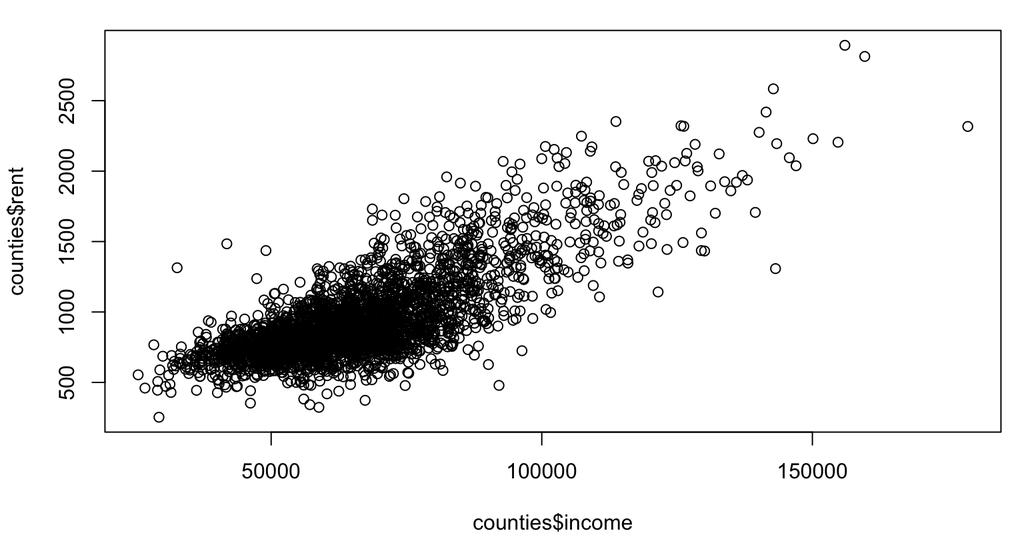

## A bunch of hidden defaults we can fill ourselves

```r
plot(
    counties$income / 1000, counties$rent,
    main = "Rent vs. income",
    xlab = "Median household income (in thousands USD)",
    ylab = "Median gross rent",
    pch = 19, cex = 0.5, col = "steelblue"
)
```

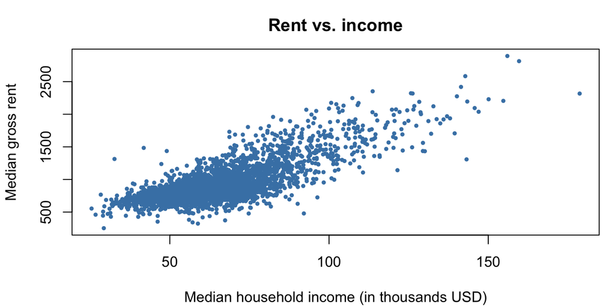

## Useful plot arguments

| Argument | What it controls | Example |
| --- | --- | --- |
| `main` | title | `main = "Rent vs. income"` |
| `xlab`, `ylab` | axis labels | `xlab = "Income"` |
| `col` | color | `col = "steelblue"` |
| `pch` | point shape | `pch = 19` (filled circle) |
| `cex` | point size | `cex = 0.5` (half size) |
| `type` | points vs. lines | `type = "l"` |
| `lwd`, `lty` | line width, line style | `lwd = 2, lty = "dashed"` |

The same arguments work across `plot()`, `lines()`, `points()`, `hist()`, and friends

Menus: [`?points`](https://stat.ethz.ch/R-manual/R-devel/library/graphics/html/points.html) draws every `pch`, [`?par`](https://stat.ethz.ch/R-manual/R-devel/library/graphics/html/par.html) covers the rest, `colors()` lists all 657 names

# ggplot2

## From canvas to objects

Base R: call functions, ink appears on a device. The plot is a **side effect.**

`ggplot2`: builds an object that describes a plot with layers. Gets drawn when you print it.

That means you can assign, modify, combine, save, etc. *without printing anything*.

```r
p <- ggplot(...) # nothing drawn yet
p # drawn now
```

`ggplot2` is part of the tidyverse you met yesterday:

```r
library(tidyverse)
```

## The gist: (data w/ mapping) + geom + …

```r
ggplot(counties, aes(x = income, y = rent)) +
    geom_point()
```

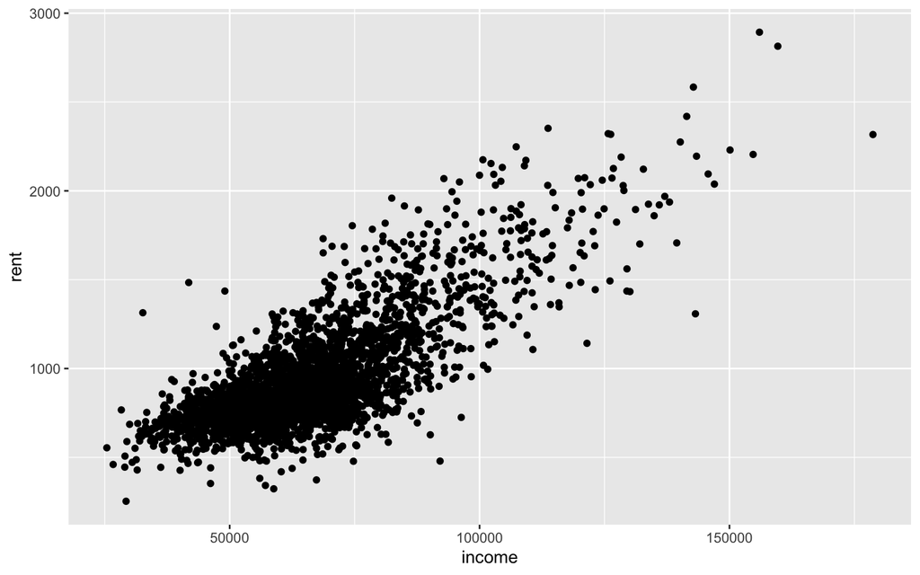

(Yuck.)

## Aesthetics

Map a third column to color. It’s a variable, so it goes in `aes()` (constants go in `geom_*`)

```r
ggplot(counties, aes(x = income, y = rent, color = region)) +
    geom_point(size = 0.7)
```

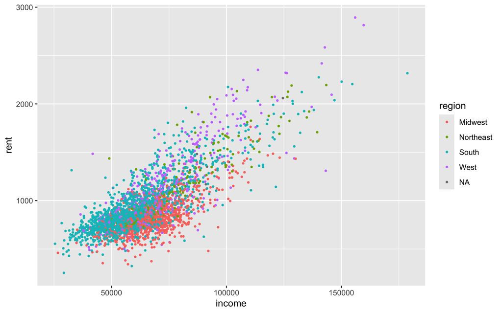

## Classic mistake

```r
ggplot(counties, aes(x = income, y = rent, color = "steelblue")) +
    geom_point(size = 0.7)
```

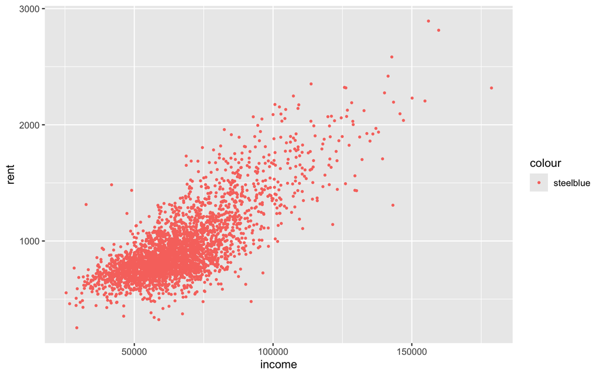

Inside `aes()`, `"steelblue"` isn’t a color. It gets vectorized as data.

## Same mapping, different geom

Distributions by group:

```r
ggplot(counties, aes(x = region, y = income)) +
    geom_boxplot()
```

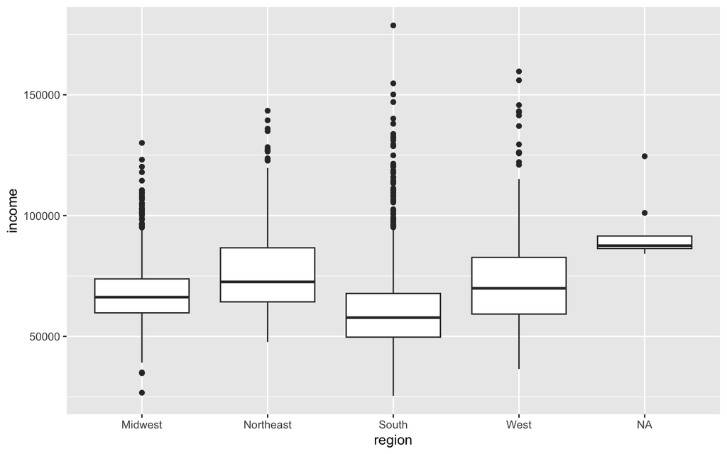

## Composition: stacked bars

Split each region’s counties into high- and low-population halves:

```r
counties <- counties |>
    mutate(pop_level = if_else(
        pop >= median(counties$pop, na.rm = T),
        "high pop", "low_pop"
    ))

counties |>
    filter(!is.na(pop_level)) |>
    ## piping in this data; now different operator!
    ggplot(aes(x = region, fill = pop_level)) +
    geom_bar()
```

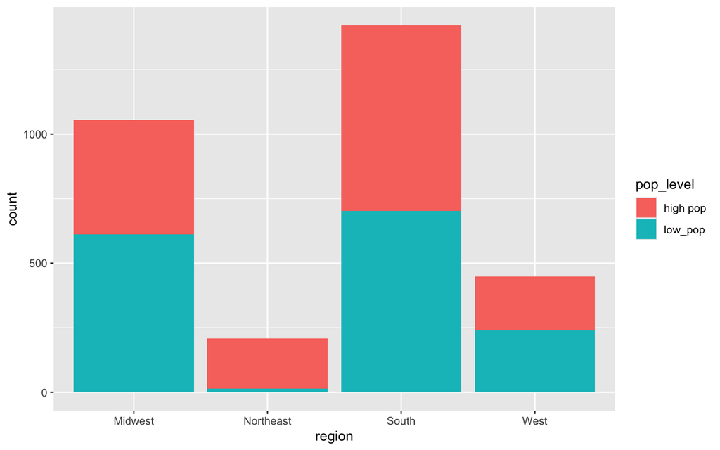

## Counts vs. shares: `position`

`position = "fill"` rescales every bar to 1

```r
counties |>
    filter(!is.na(pop_level)) |>
    ggplot(aes(x = region, fill = pop_level)) +
    geom_bar(position = "fill")
```

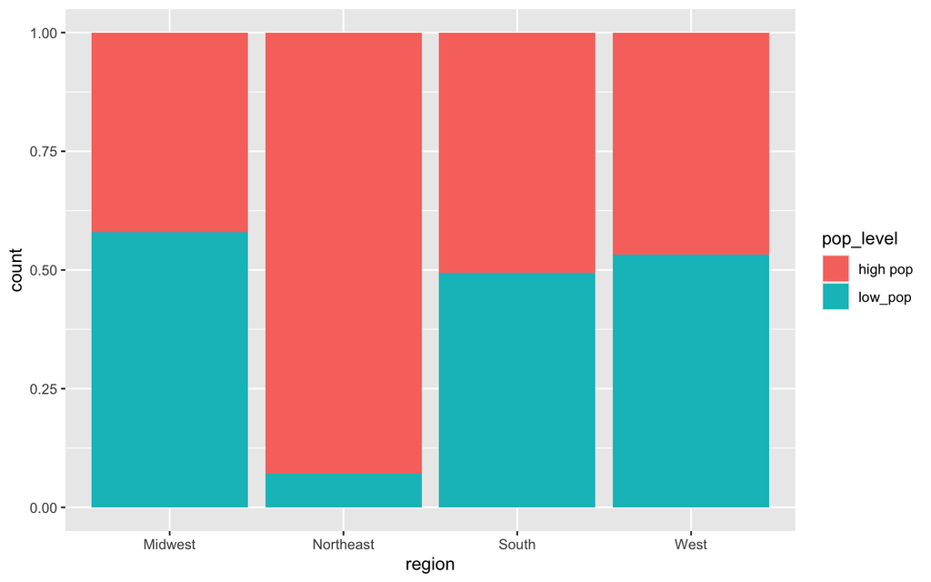

## Side by side: `position = "dodge"`

```r
counties |>
    filter(!is.na(pop_level)) |>
    ggplot(aes(x = region, fill = pop_level)) +
    geom_bar(position = "dodge")
```

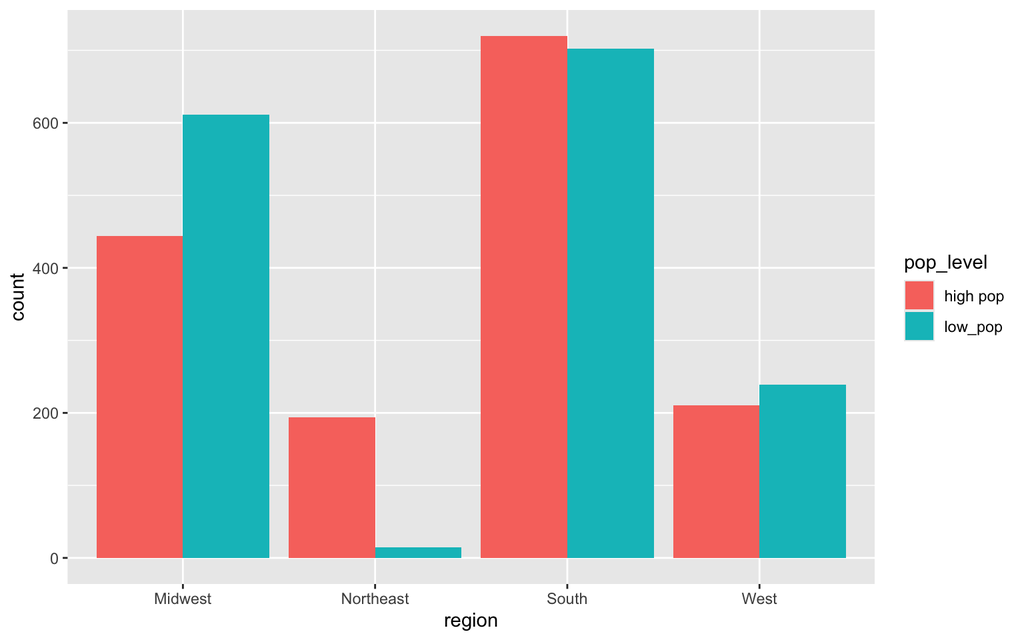

*Three versions of the same bars — stacked, filled, dodged. Which question does each answer best?*

## Line graphs

`ggplot2` ships with practice data: `economics` is monthly US macro data:

```r
ggplot(economics, aes(x = date, y = unemploy)) +
    geom_line()
```

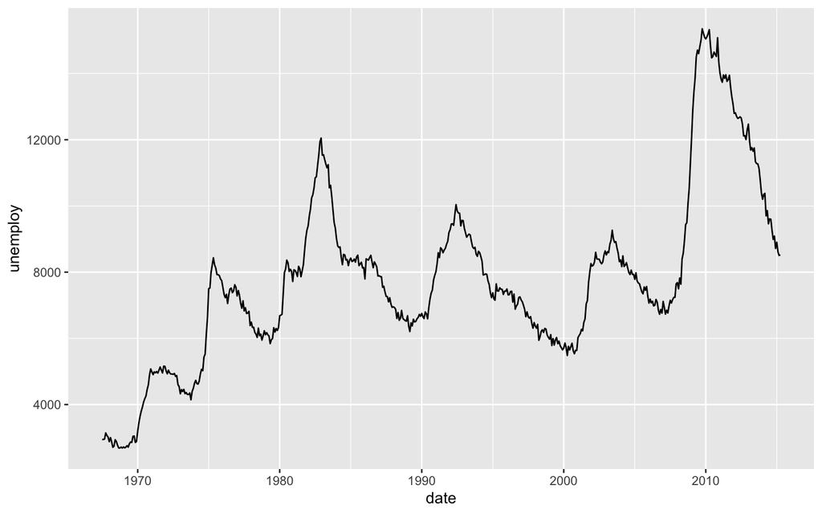

## Common mistake

```r
head(economics_long, 3)
```

```
# A tibble: 3 × 4
  date       variable value  value01
  <date>     <chr>    <dbl>    <dbl>
1 1967-07-01 pce       507. 0
2 1967-08-01 pce       510. 0.000265
3 1967-09-01 pce       516. 0.000762
```

```r
ggplot(economics_long, aes(x = date, y = value01)) +
    geom_line()
```

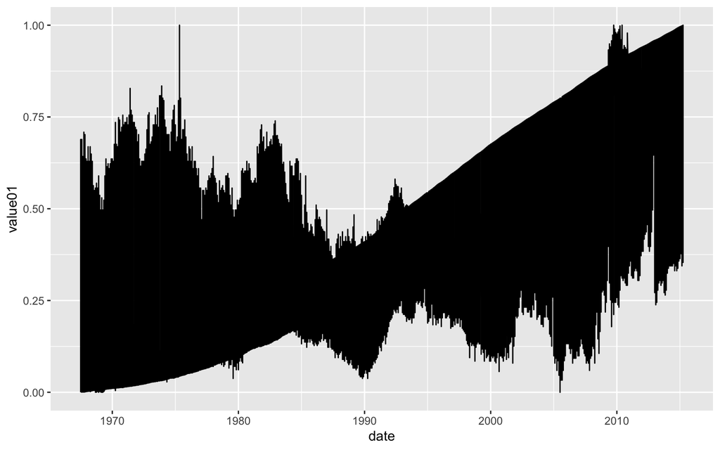

## Tell ggplot what belongs together

Map the series id to `color` (or `group`) and each variable gets its own line:

```r
ggplot(economics_long, aes(x = date, y = value01, color = variable)) +
    geom_line()
```

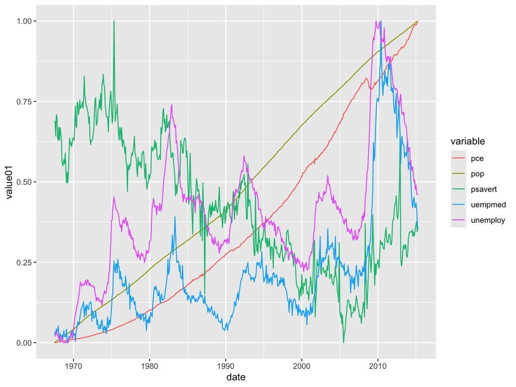

## Reference lines are geoms too

`geom_hline()`, `geom_vline()`, and `geom_abline()` are just more layers:

```r
ggplot(counties, aes(x = income, y = rent)) +
    geom_point(size = 0.5, color = "gray") +
    geom_hline(
        yintercept = median(counties$rent, na.rm = T),
        color = "steelblue", linewidth = 1
    )
```

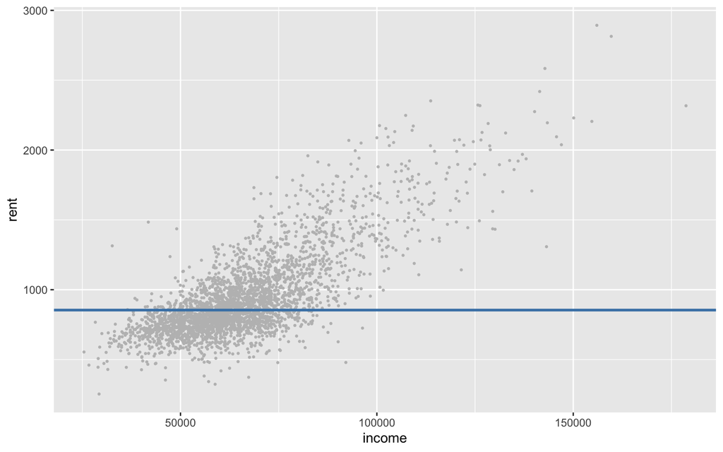

## Facets

One line splits the plot by a categorical column:

```r
ggplot(counties, aes(x = income, y = rent)) +
    geom_point(size = 0.4) +
    facet_wrap(~region) ## more than one: ~ region + ...
```

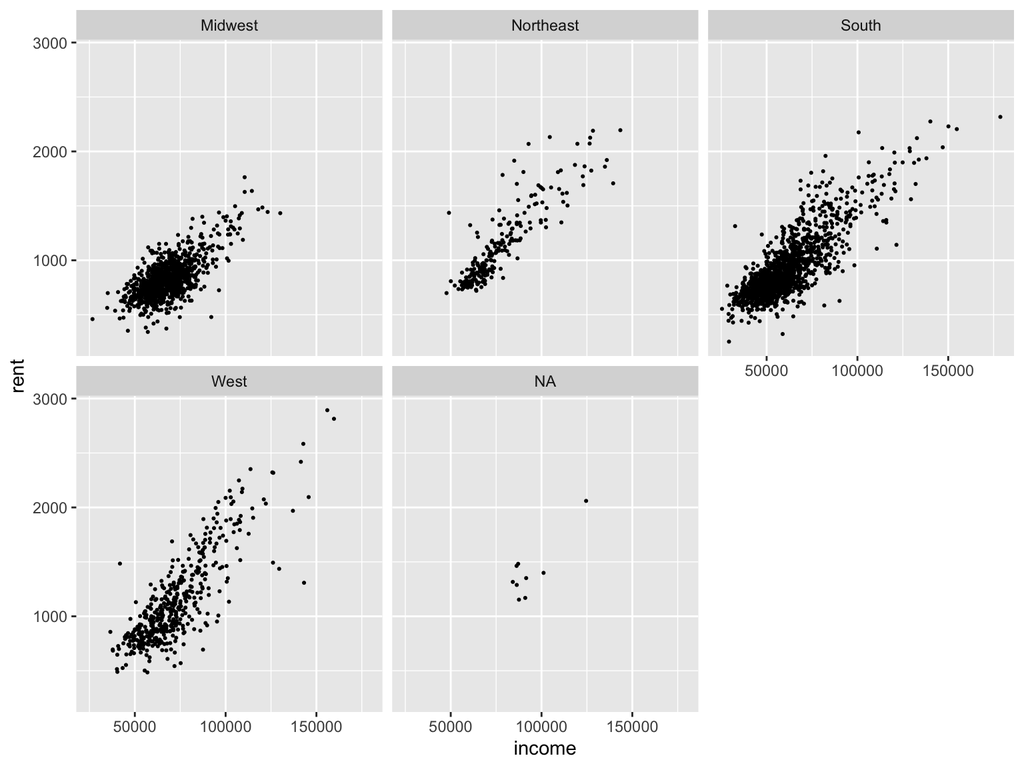

## Facets in two directions

`facet_grid(rows ~ cols)`:

```r
counties |>
    filter(!is.na(pop_level)) |>
    ggplot(aes(x = income, y = rent)) +
    geom_point(size = 0.4) +
    facet_grid(pop_level ~ region)
```

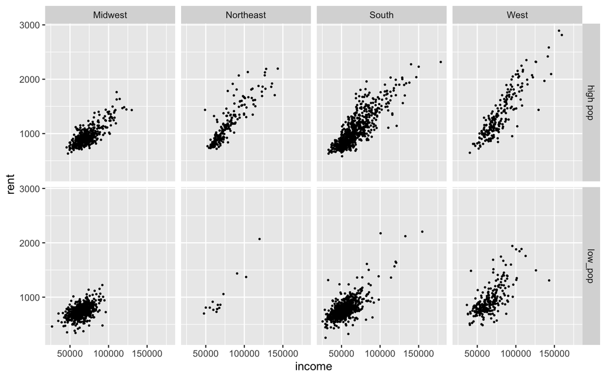

## Labels with `labs()`

```r
ggplot(counties, aes(x = income, y = rent, color = region)) +
    geom_point(size = 0.7) +
    labs(
        title = "Rent rises with income",
        subtitle = "US counties, 2023 five-year ACS",
        x = "Median household income ($)",
        y = "Median gross rent ($)",
        color = "Region"
    )
```

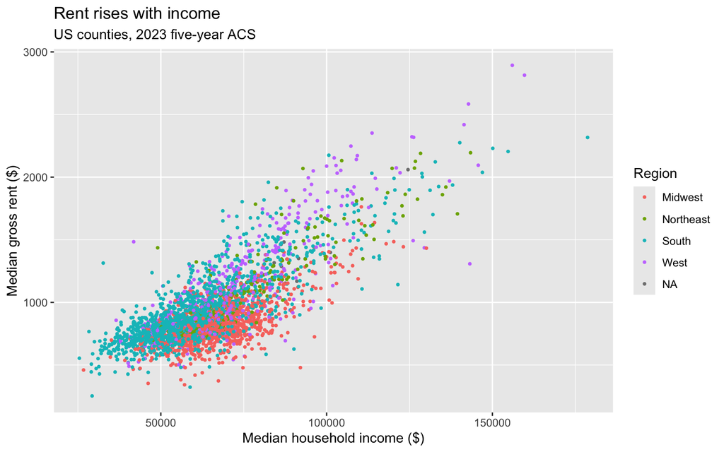

## Scales: *how* mappings become positions and colors

Every aesthetic has a scale named `scale_<aesthetic>_<flavor>()` with its own arguments:

```r
ggplot(counties, aes(x = income, y = rent)) +
    geom_point(size = 0.5) +
    scale_x_continuous(
        name = "Median household income",
        breaks = c(50000, 100000, 150000),
        labels = c("$50k", "$100k", "$150k"),
        limits = c(0, 200000)
    )
```

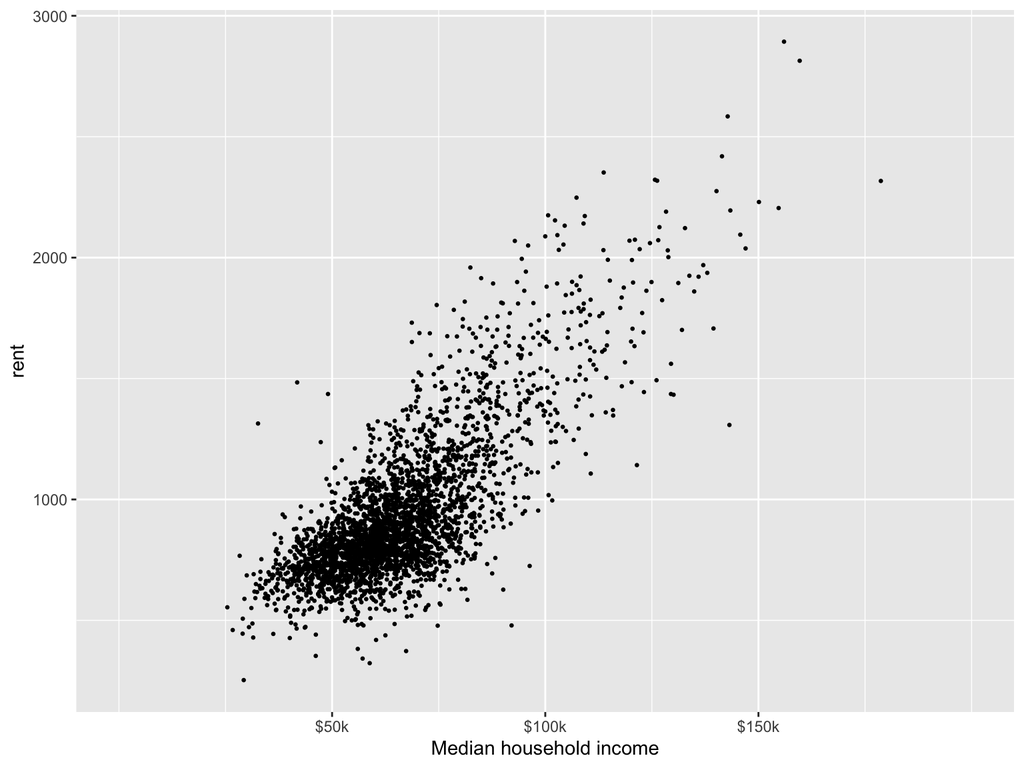

## Zooming vs. dropping

`xlim()`/`ylim()`/`lims()` **throw away data** outside the limits:

```r
ggplot(counties, aes(x = income, y = rent)) +
    geom_point(size = 0.5) +
    lims(x = c(0, 100000))
```

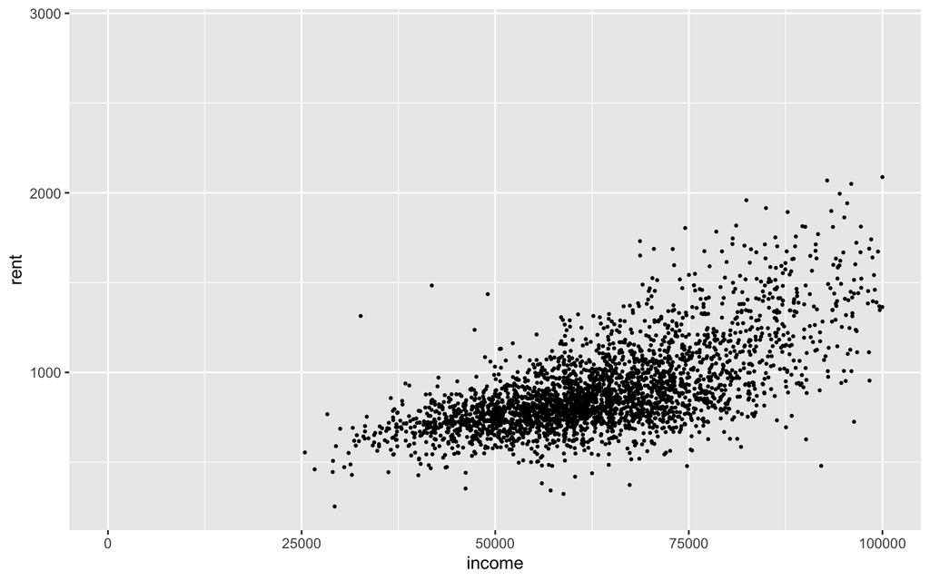

## Zooming vs. dropping

`coord_cartesian()` **zooms** without dropping:

```r
ggplot(counties, aes(x = income, y = rent)) +
    geom_point(size = 0.5) +
    coord_cartesian(xlim = c(0, 100000))
```

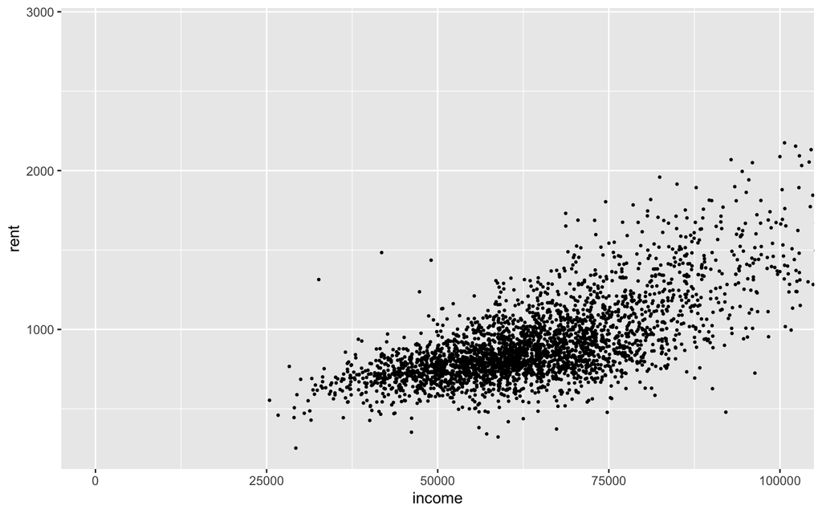

Looks the same here, but anything *computed* from the data (boxplot stats, smoothers, densities) changes when points are dropped.

## Other `geom_*` functions

- [Function reference](https://ggplot2.tidyverse.org/reference/) — every geom with pictures
- [Aesthetic specifications](https://ggplot2.tidyverse.org/articles/ggplot2-specs.html) — every `shape` number, `linetype` name, and color

You’ll google `ggplot geom` + what you want to draw (or ask Claude).

There is also a `stat_*()` family for layers that include on-the-fly statistical transformations. See [here](https://ggplot2.tidyverse.org/reference/layer_stats.html).

## Setup for next bit

```r
p <- ggplot(counties, aes(x = income, y = rent, color = region)) +
    geom_point(size = 0.6) +
    labs(
        x = "Median household income ($ logged)",
        y = "Median gross rent ($)",
        color = NULL
    ) +
    scale_x_log10()

p
```

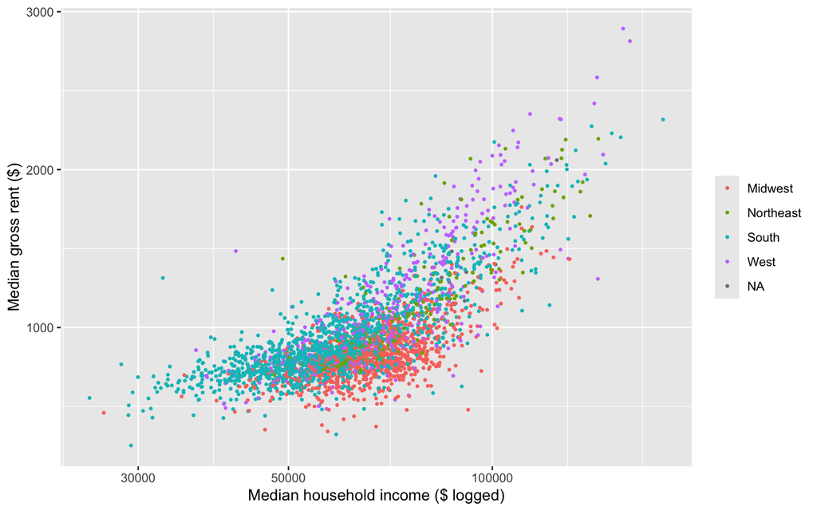

## Themes

Complete themes restyle everything at once:

```r
p + theme_bw()
```

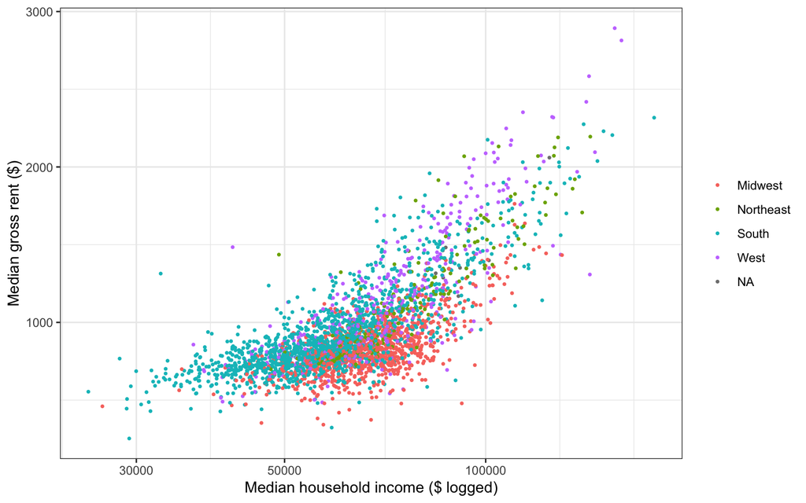

Try `theme_minimal()`, `theme_bw()`, `theme_classic()`, `theme_void()`, etc. and packages like `ggthemes` for more.

## Scale your fonts to the medium

Every complete theme takes `base_size` to scale *all* the text together.

Paper figures ≈ 11, but slides need much more:

```r
p + theme_minimal(base_size = 20)
```

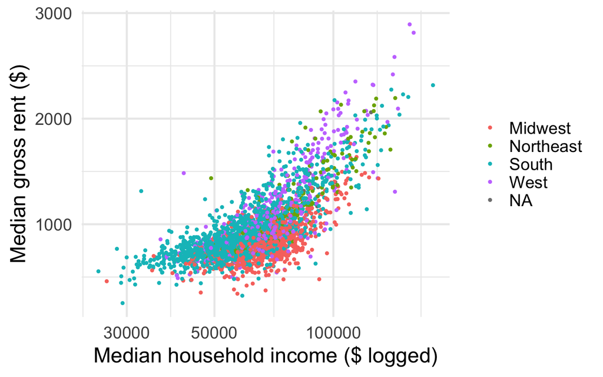

Foreshadowing: What matters is font size *relative to the figure*. Save the same plot smaller and every label looks bigger.

## Or size each piece separately

`theme()` targets one element at a time. Elements take an `element_*()`:

```r
p + theme_minimal(base_size = 15) +
    theme(
        axis.title.x = element_text(size = 20, face = "bold"),
        axis.text    = element_text(size = 10),
        legend.text  = element_text(size = 12, family = "Palatino")
    )
```

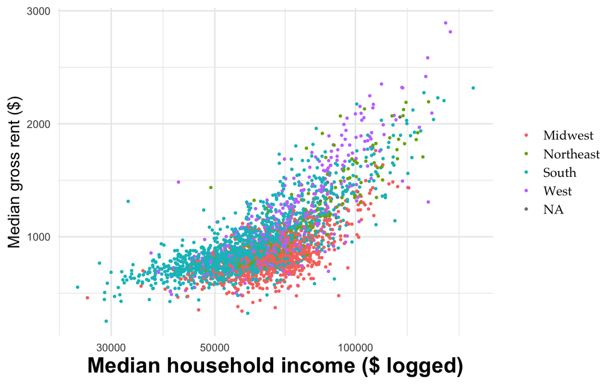

## The `element_*()` family

- `element_text()`, `element_line()`
- `element_rect()` — backgrounds and borders
- `element_blank()` — removes the element

```r
p + theme_bw(base_size = 15) + theme(panel.grid = element_blank())
```

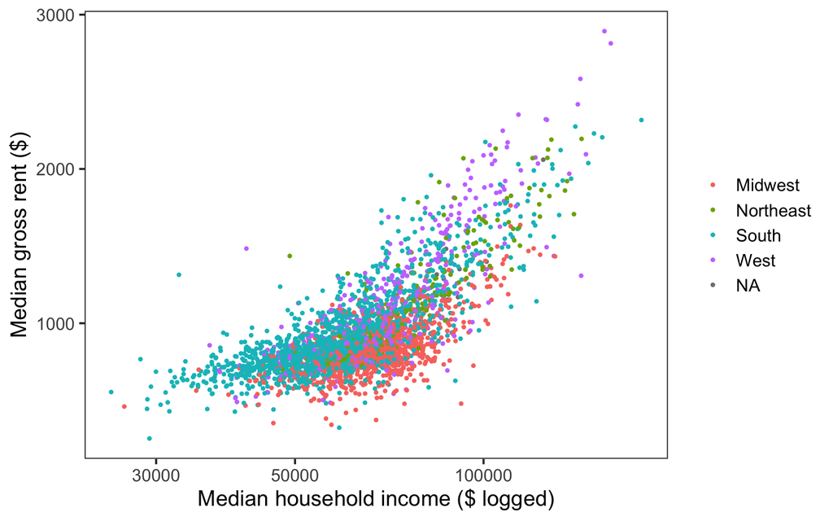

A complete theme *resets everything before it*.

## Color palettes

Pick non-default colors or it looks like you didn’t try.

```r
p + theme_minimal(base_size = 15) + scale_color_viridis_d()
```

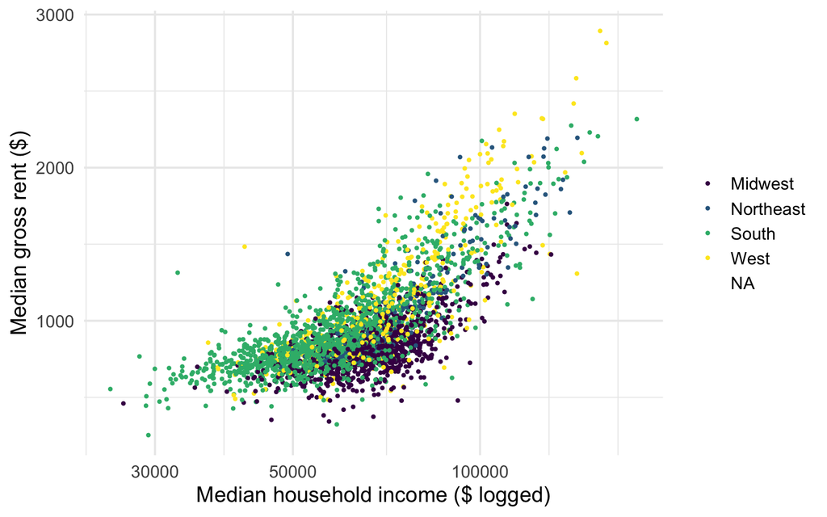

`viridis` is colorblind-safe and printer-safe. `scale_*_brewer()` uses [ColorBrewer](https://colorbrewer2.org). There are many packages (`paletteer`, `MetBrewer`, etc)

## Or make your own

```r
pal <- c(
    "Midwest" = "#E87722", "Northeast" = "steelblue",
    "South" = "firebrick", "West" = "#83876F"
)

p + theme_minimal(base_size = 15) + scale_color_manual(values = pal)
```

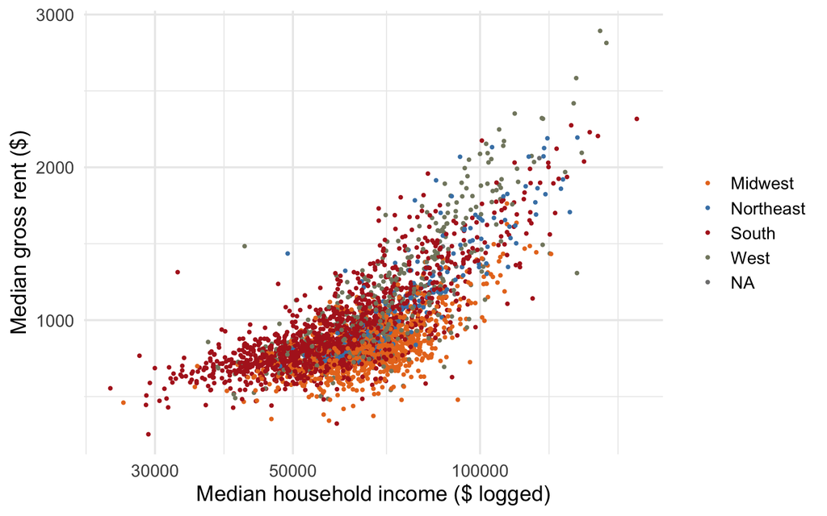

## Composing figures: `patchwork`

A package can define `+`, `|`, and `/` on `ggplot` objects:

```r
library(patchwork)

p <- p + theme_minimal(base_size = 15)

box <- ggplot(counties, aes(x = region, y = income)) +
    geom_boxplot() +
    theme_minimal(base_size = 15)

p + box
```

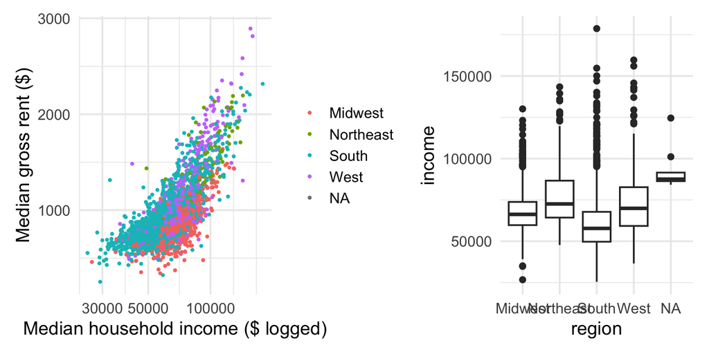

## `patchwork` layouts

`|` puts plots beside each other; `/` stacks them:

```r
hist_inc <- ggplot(counties, aes(x = income)) +
    theme_minimal(base_size = 15) +
    geom_histogram(bins = 40)

(p | box) / hist_inc
```

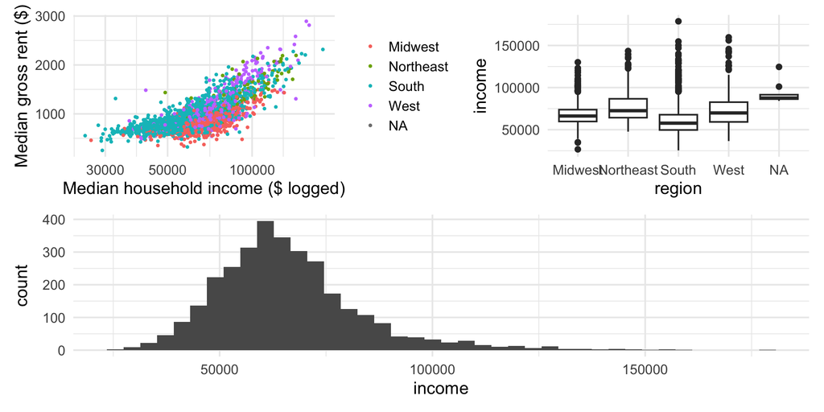

What’s wrong here?

# Publication-ready figures

## Figures are programmatic outputs

Your figures are *products of your code*, same as your tables and estimates

- Rerun the script, get the figure without clicking through export UI boxes
- Change the data and every figure updates

Never screenshot a plot. If a figure matters enough to share, save it properly at full resolution using code you can rerun.

## Saving plots properly with `ggsave()`

```r
ggsave("rent_income.pdf", p, width = 6, height = 4)
```

`ggsave()` infers the format from the extension; `width`/`height` are in inches (change with `units` arg).

Tip: Set `width`/`height` to the actual size in your document and the figures will be proportioned correctly.

For base R plots the equivalent is: `pdf("fig.pdf", width = 6, height = 4)`, plot, then `dev.off()`

## Vector > raster

|  | Formats | What’s stored | Zoom in and… |
| --- | --- | --- | --- |
| **Vector** | `pdf`, `svg`, `eps` | shapes and text | stays perfectly crisp |
| **Raster** | `png`, `jpg` | a grid of pixels | gets blurry |

Use vector formats whenever you can: LaTeX and Word take `pdf`; the web takes `svg`

When you’re *forced* to raster (some journals, slides software), set `dpi = 300` or more in `ggsave()`

# Maps

## Maps are just plots

The `sf` package reads geographic files and gives each row a `geometry` column:

```r
library(sf)
shapes <- st_read("county_shapes.geojson")
```

It looks like a data frame with a special column:

```r
head(shapes, 3)
```

```
Simple feature collection with 3 features and 3 fields
Geometry type: MULTIPOLYGON
Dimension:     XY
Bounding box:  xmin: 80165.29 ymin: 60653.63 xmax: 1717985 ymax: 527895.3
Projected CRS: USA_Contiguous_Albers_Equal_Area_Conic
  GEOID    state          county                       geometry
1 18087  Indiana LaGrange County MULTIPOLYGON (((851901.1 52...
2 20107   Kansas     Linn County MULTIPOLYGON (((80824.31 10...
3 24029 Maryland     Kent County MULTIPOLYGON (((1689187 389...
```

## Maps, the ggplot way

First attach our county numbers to the shapes:

```r
shapes_data <- shapes |>
    left_join(
        counties |> select(GEOID, income, rent),
        join_by(GEOID)
    )

head(shapes_data, 3)
```

```
Simple feature collection with 3 features and 5 fields
Geometry type: MULTIPOLYGON
Dimension:     XY
Bounding box:  xmin: 80165.29 ymin: 60653.63 xmax: 1717985 ymax: 527895.3
Projected CRS: USA_Contiguous_Albers_Equal_Area_Conic
  GEOID    state          county income rent                       geometry
1 18087  Indiana LaGrange County  83741  816 MULTIPOLYGON (((851901.1 52...
2 20107   Kansas     Linn County  59200  682 MULTIPOLYGON (((80824.31 10...
3 24029 Maryland     Kent County  74402 1144 MULTIPOLYGON (((1689187 389...
```

## Maps, the ggplot way

This could not be easier:

```r
shapes_data |>
    ggplot() +
    geom_sf()
```

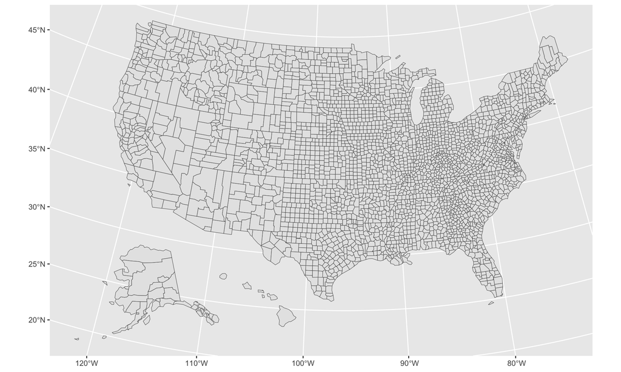

## Maps, the ggplot way

`geom_sf()` is a geom like any other — aesthetics, scales, and themes all apply:

```r
ggplot(shapes_data) +
    geom_sf(aes(fill = income), linewidth = 0.05) +
    scale_fill_viridis_c(
        name = "Median income",
        breaks = c(50000, 100000, 150000),
        labels = c("$50k", "$100k", "$150k")
    ) +
    theme_void(base_size = 15)
```

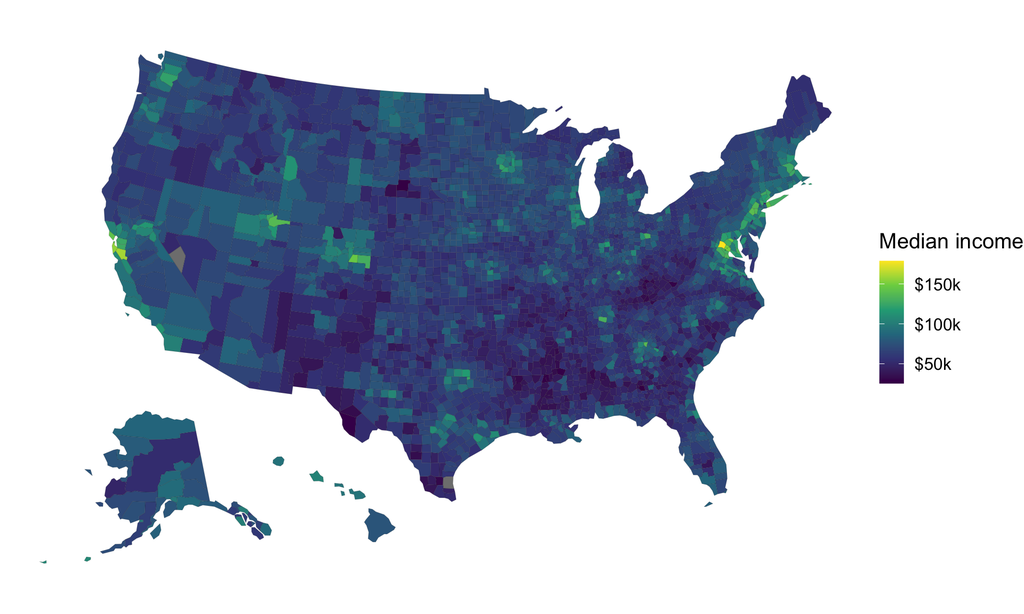

## Pivoting for `facet_*()`

To facet by variable, the variables must live in *one* column — `tidyr`’s `pivot_longer()` stacks them:

```r
long <- shapes_data |> pivot_longer(c(income, rent))

long |>
    select(county, name, value) |>
    head(4)
```

```
Simple feature collection with 4 features and 3 fields
Geometry type: MULTIPOLYGON
Dimension:     XY
Bounding box:  xmin: 80165.29 ymin: 60653.63 xmax: 893059.9 ymax: 527895.3
Projected CRS: USA_Contiguous_Albers_Equal_Area_Conic
# A tibble: 4 × 4
  county          name   value                                        geometry
  <chr>           <chr>  <dbl>                              <MULTIPOLYGON [m]>
1 LaGrange County income 83741 (((851901.1 523582.1, 855179.6 497385.5, 89305…
2 LaGrange County rent     816 (((851901.1 523582.1, 855179.6 497385.5, 89305…
3 Linn County     income 59200 (((80824.31 100142.8, 80165.29 60653.63, 12048…
4 Linn County     rent     682 (((80824.31 100142.8, 80165.29 60653.63, 12048…
```

## Multiple maps

Income dollars dwarf rent dollars, so give each variable its own percentiles, then facet:

```r
long <- long |>
    group_by(name) |>
    mutate(percentile = percent_rank(value))

ggplot(long) +
    geom_sf(aes(fill = percentile), linewidth = 0.02) +
    scale_fill_viridis_c() +
    facet_wrap(~name) +
    theme_void(base_size = 15)
```

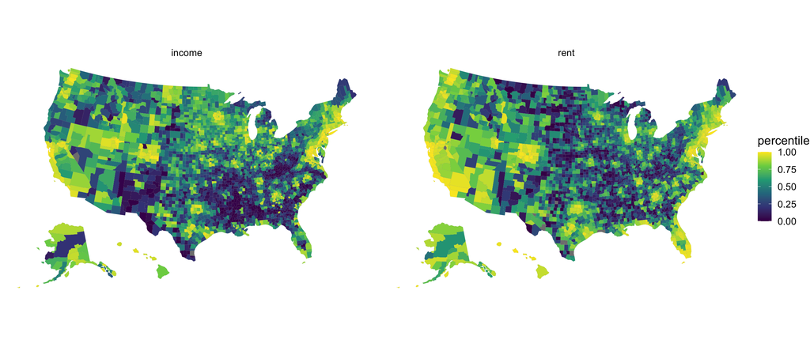

## For spatial data, resolution matters

Boundary files often store more detail than we can see. Use `st_simplify()` for plot files if necessary:

```r
# this renders weirdly sometimes:
rough <- st_simplify(shapes, dTolerance = 25000, preserveTopology = T)
```

Ours is pre-simplified (1.8 MB); raw Census files run much larger and image files will be too large – and view rendering will take too long.

The `tigris` package (USA) has `cb` and `resolution` arguments for this.

## This afternoon

- Version control with git and GitHub
- Distributions and random draws
- Big exercise: a version-controlled, simulated analysis — start to finish

princeton-ddss.github.io/r-bootcamp

## Now: plotting exercise

Open the exercise Quarto: princeton-ddss.github.io/r-bootcamp/notes/day-3-viz-ex.qmd

Open the exercise PDF instructions (if you want): princeton-ddss.github.io/r-bootcamp/notes/day-3-viz-ex.pdf

- A Quarto report with empty chunks — fill them in and render as you go
- Everything you need is from this morning